# Report

Yang Xia

2017/11/13

#### Specifications of host execution Environment

| Attribute | Value |
| --- | --- |
| Java Version | 1.8.0_102 |
| Spark Version | 2.2.0 |
| Model Identifier | MacBookPro13,2 |
| Processor Name | Intel Core i5 |
| Processor Speed | 2.2 GHz |
| Number of Processors | 1 |
| Total Number of Cores | 4 |
| Memory | 16 GB |
| Driver Memory | 2 GB |
| Executor Memory | 2 GB |

### Summary of the design

The implementation start with reading the data. I had a class called “SongInfo” which store the related information as fileds. This makes the code cleaner. I didn’t do the so-called clean-up test before hand due to the fact that this might cause inaccuracy in the result. The milionSong object is the entry point to the program that taken in song_info.csv and artist_terms.csv locations in the input file and calls the methods in the SongInfo class to get the desired output.

## Result Analysis

#### Assumptions

Even if one of the cell is empty or doesn’t have the correct value, the other part of the record is invalid.

For the whole dataset:

#### Number of distinct songs: 999056

#### Number of distinct artists: 44745

#### Number of distinct albums: 149275

#### Top 5 loudest songs:

(Assumption: a larger loudness implies a louder song)

| Song Id | Song Name | Loudness Score |
| --- | --- | --- |
| SOCMYZF12AB0186FF4 | Modifications | 4.318 |
| SONHDXQ12AB018C1F1 | Track 02 | 4.3 |
| SOZCIHV12AC46894E3 | Hey You Fuxxx! | 4.231 |
| SOEJMJF12AC90715D1 | War Memorial Exit | 4.166 |
| SOBEMPS12A8C13BD46 | Meta Abuse | 4.15 |

#### Top 5 longest songs:

(Assumption: a larger duration implies a longer song)

| Song Id | Song Name | Duration |
| --- | --- | --- |
| SOOUBST12AC90977B6 | Grounation | 3034.90567 |
| SOXUCQN12A6D4FC451 | Raag - Shuddha KalyaN | 3033.5995 |
| SOOMVZJ12AB01878EB | Discussion 2 | 3033.44281 |
| SOTNVEE12A8C13F470 | Chapitre Un (a): Toutes Les Histoires | 3032.76363 |
| SOGFXNB12A8C137BE5 | Der Geist des Llano Estacado Ein Spion | 3032.58077 |

#### Top 5 fastest songs:

(Assumption: a larger tempo implies a faster song)

| Song Id | Song Name | Tempo Score |
| --- | --- | --- |
| SOVVTEZ12AB0184AAB | Beep Beep | 302.3 |
| SOMSJWX12AB017DB99 | Late Nite Lounge: WVIP | 296.469 |
| SOUTBKH12A8C136286 | A Place Called Hope | 285.157 |
| SOEVQJB12AC960DA2C | Bellas Lullaby - Perrier Citron | 284.208 |
| SOTUXOB12AB0188C3A | Troubled Times | 282.573 |

#### Top 5 most familiar artists:

| Artist Name | Artist Id | Familiarity Score |
| --- | --- | --- |
| Akon | ARCGJ6U1187FB4D01F | 1.0 |
| Akon_ San Quinn_ JT the Bigga Figga | ARCGJ6U1187FB4D01F | 1.0 |
| Akon / Eminem | ARCGJ6U1187FB4D01F | 1.0 |
| Akon / Styles P | ARCGJ6U1187FB4D01F | 1.0 |
| Akon / Wyclef Jean | ARCGJ6U1187FB4D01F | 1.0 |

#### Top 5 hottest artists:

| Artist Name | Artist Id | Hotness Score |
| --- | --- | --- |
| Daft Punk | ARF8HTQ1187B9AE693 | 0.997066533839045 |
| Daft Punk | ARF8HTQ1187B9AE693 | 0.997004803235357 |
| Black Eyed Peas | ARTDQRC1187FB4EFD4 | 0.982623202516712 |
| Kanye West | ARRH63Y1187FB47783 | 0.972399563931911 |
| Kanye West / Jamie Foxx | ARRH63Y1187FB47783 | 0.972399563931911 |

##### Top 5 hottest songs:

[output not shown]

#### Top 5 hottest genres (mean artists hotness in artist_term)

| Genres | Mean Hotness |
| --- | --- |
| christmas song | 0.6084021 |
| kotekote | 0.6022205 |
| female artist | 0.5753481 |
| girl rockers | 0.5737886 |
| alternative latin | 0.5737588 |

##### Top 5 Prolific artists:

| Artist Id | Artist Name | Number of songs by the artist |
| --- | --- | --- |
| AR6681Y1187FB39B02 | Ike & Tina Turner | 208 |
| ARXPPEY1187FB51DF4 | Michael Jackson | 204 |
| ARH861H1187B9B799E | Johnny Cash | 201 |
| AR8L6W21187B9AD317 | Diana Ross & The Supremes | 196 |
| ARLHO5Z1187FB4C861 | Beastie Boys | 194 |

#### Top 5 most popular keys (must have confidence > 0.7):

| Key | Ocurrances |
| --- | --- |
| 7 | 53144 |
| 9 | 46855 |
| 2 | 46431 |
| 4 | 35099 |
| 11 | 35078 |

#### Top 5 most common words in song titles (excluding articles, prepositions, conjunctions):

(Assumption: (ablum version) doesn’t count as part of the title)

| Word | Ocurrances |
| --- | --- |
| LOVE | 9882 |
| LIVE | 6192 |
| YOUR | 5333 |
| NO | 4822 |
| REMIX | 4462 |

### Performance Analysis

#### Times taken for different operations on **entire data with persist**:

```
##    Task              Query performed
## 1     1          Find distinct songs
## 2     2        Find distinct artists
## 3     3         Find distinct albums
## 4     4     Find top 5 loudest songs
## 5     5     Find top 5 longest songs
## 6     6     Find top 5 fastest songs
## 7     7     Find top 5 hottest songs
## 8     8  Find top 5 familiar artists
## 9     9   Find top 5 hottest artists
## 10   10    Find top 5 hottest Genres
## 11   11 Find top 5 most popular keys
## 12   12  Find top 5 prolific artists
## 13   13      Find top 5 common words
```

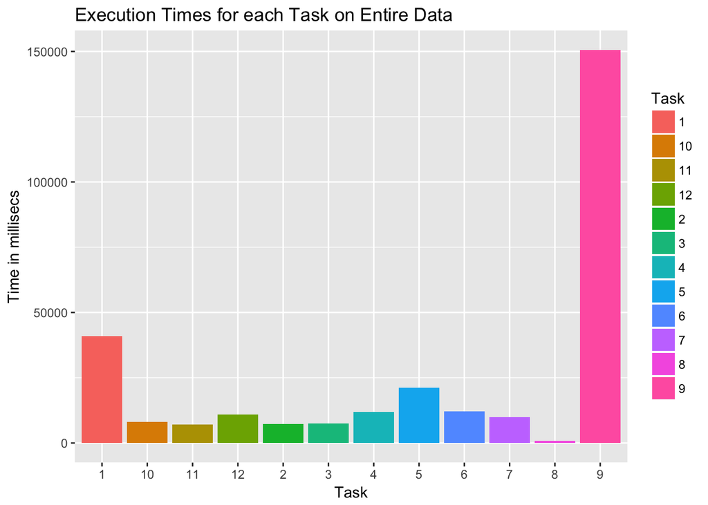

####Times taken for different operations on the **entire data without persist**:

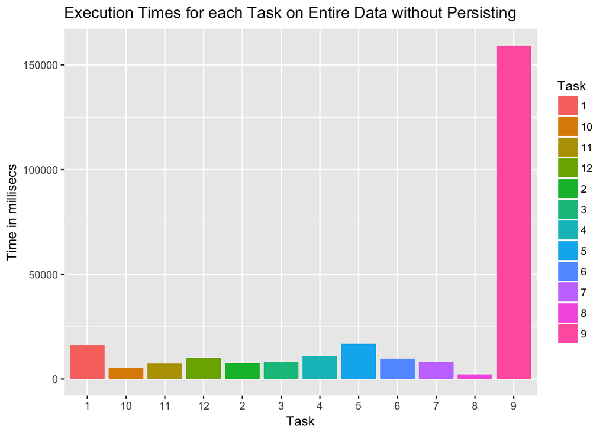

### Conclusion

This program takes million songs data as input and do some simple analysis on the whole dataset. Using Spark instead of Hadoop saves a lot of effort. Though I’ve never implemented in hadoop, I can imagine doing the same things in Hadoop require many map job and reduce job, which in most of the cases are not as efficient as I did here with spark. The bottleneck here is the join operation; some optimization could be done to improve the performance. In a stand-alone mod, persist does not give me the speed-up as it should be while in a distributed mode.